# ChIP-seq datasets for FDR benchmarking

Mingxiang Teng

December 20, 2017

### Summary

For FDR benchmark using ChIP-seq datasets, we may focus on peak calling and differential peaks. Peak calling has been the most common procedure to analyze ChIP-seq since this technique was invented, though people started to look into differential peaks in some complex experiment designs. In peak calling, callers always report effect size (they call “enrichment signal”) and p-value, but standard error. It is complicate to hack the original code for re-generating standard errors. In differential peaks, classical pipelines firstly call peaks, and recruit existing algorithms (*i.e.* edgeR/DESeq2) to test the covariant of interest later, in a way that the effect size, p-value and standard error can be generated at the same time.

Here, we focus on test the differential peaks. It is noted that by using DESeq2 to test the differential peaks, we have introduced similarity into testing results to that we used for RNA-seq differential analysis. Nevertheless, benchmarking on ChIP-seq still provides insights with a unique data structure which has been widely utilized in modern genomics.

### Testing differential ChIP-seq signals between two cell lines (K562 *vs.* Gm12878)

These two cell lines hold the largest sequencing datasets in ENCODE project. We chose histone H3K4Me3 ChIP-seq data for our analysis here.

#### Data Download

We downloaded the bam files directly from UCSC ENCODE protal.

```bash
wget -N -P data http://hgdownload.soe.ucsc.edu/goldenPath/hg19/encodeDCC/wgEncodeBroadHistone/wgEncodeBroadHistoneGm12878H3k4me3StdAlnRep1.bam
wget -N -P data http://hgdownload.soe.ucsc.edu/goldenPath/hg19/encodeDCC/wgEncodeBroadHistone/wgEncodeBroadHistoneGm12878H3k4me3StdAlnRep1.bam.bai
wget -N -P data http://hgdownload.soe.ucsc.edu/goldenPath/hg19/encodeDCC/wgEncodeBroadHistone/wgEncodeBroadHistoneGm12878H3k04me3StdAlnRep2V2.bam
wget -N -P data http://hgdownload.soe.ucsc.edu/goldenPath/hg19/encodeDCC/wgEncodeBroadHistone/wgEncodeBroadHistoneGm12878H3k04me3StdAlnRep2V2.bam.bai
wget -N -P data http://hgdownload.soe.ucsc.edu/goldenPath/hg19/encodeDCC/wgEncodeBroadHistone/wgEncodeBroadHistoneK562H3k4me3StdAlnRep1.bam
wget -N -P data http://hgdownload.soe.ucsc.edu/goldenPath/hg19/encodeDCC/wgEncodeBroadHistone/wgEncodeBroadHistoneK562H3k4me3StdAlnRep1.bam.bai
wget -N -P data http://hgdownload.soe.ucsc.edu/goldenPath/hg19/encodeDCC/wgEncodeBroadHistone/wgEncodeBroadHistoneK562H3k4me3StdAlnRep2.bam
wget -N -P data http://hgdownload.soe.ucsc.edu/goldenPath/hg19/encodeDCC/wgEncodeBroadHistone/wgEncodeBroadHistoneK562H3k4me3StdAlnRep2.bam.bai
wget -N -P data http://hgdownload.soe.ucsc.edu/goldenPath/hg19/encodeDCC/wgEncodeUwHistone/wgEncodeUwHistoneGm12878H3k4me3StdAlnRep1.bam
wget -N -P data http://hgdownload.soe.ucsc.edu/goldenPath/hg19/encodeDCC/wgEncodeUwHistone/wgEncodeUwHistoneGm12878H3k4me3StdAlnRep1.bam.bai
wget -N -P data http://hgdownload.soe.ucsc.edu/goldenPath/hg19/encodeDCC/wgEncodeUwHistone/wgEncodeUwHistoneGm12878H3k4me3StdAlnRep2.bam
wget -N -P data http://hgdownload.soe.ucsc.edu/goldenPath/hg19/encodeDCC/wgEncodeUwHistone/wgEncodeUwHistoneGm12878H3k4me3StdAlnRep2.bam.bai
wget -N -P data http://hgdownload.soe.ucsc.edu/goldenPath/hg19/encodeDCC/wgEncodeUwHistone/wgEncodeUwHistoneK562H3k4me3StdAlnRep1.bam
wget -N -P data http://hgdownload.soe.ucsc.edu/goldenPath/hg19/encodeDCC/wgEncodeUwHistone/wgEncodeUwHistoneK562H3k4me3StdAlnRep1.bam.bai
wget -N -P data http://hgdownload.soe.ucsc.edu/goldenPath/hg19/encodeDCC/wgEncodeUwHistone/wgEncodeUwHistoneK562H3k4me3StdAlnRep2.bam
wget -N -P data http://hgdownload.soe.ucsc.edu/goldenPath/hg19/encodeDCC/wgEncodeUwHistone/wgEncodeUwHistoneK562H3k4me3StdAlnRep2.bam.bai
```

#### Workspace Setup

Here, we first load in all R-packages needed in the analysis. As mentioned above, classical differential analysis pipeline would involve peak calling as the first step. In that case, differential testing is performed on a filtered set of genomic regions after peak calling. However, this will result in limited null tests since regions are chosen with significance at least in one condition. To address this issue, we selected ChIP-seq data of H3K4Me3 which is an active marker of gene expression. We focus our analysis on promoter regions of all genes for this histone marker. This helps avoid limited null tests with peak calling by not losing most interesting regions for this histone marker.

```r
datdir <- "data"
resdir <- "results"
# wrangling & plotting tools
library(data.table)
library(readxl)
library(readr)
library(dplyr)
library(ggplot2)
library(magrittr)
library(R.utils)
library(cowplot)
# benchmark methods
library(IHW)
library(ashr)
library(qvalue)
library(swfdr)
library(fdrtool)
library(FDRreg)
# comparison tools/functions
library(SummarizedBenchmark)
library(R.utils)
sourceDirectory("benchmark-fdr/datasets/R/")
# set up parallel backend
library(BiocParallel)
cores <- as.numeric(Sys.getenv("SLURM_NTASKS"))
multicoreParam <- MulticoreParam(workers = cores)
library(GenomicRanges)
library(TxDb.Hsapiens.UCSC.hg19.knownGene)
prom <- promoters(genes(TxDb.Hsapiens.UCSC.hg19.knownGene))
seqlevels(prom,force=T) <- seqlevels(prom)[!grepl("_", seqlevels(prom))]
bamfiles <- list.files(datdir,pattern='bam$',full=T)
labs <- rep(c('Broad','UW'),each=4)
cells <- rep(rep(c('GM12878','K562'),each=2),2)
meta <- data.frame(cellline=cells,lab=labs,file=bamfiles)
```

#### Generating Benchmarking Inputs

Basically, we count sequencing reads for all promoter regions here. We chose the average coverage across conditions and replicates as the covariate.

```r
if(file.exists('h3k4me3.rda')){
    load('h3k4me3.rda')
}else{
    library(Rsubread)
    anno <- data.frame(GeneID=seq_len(length(prom)),Chr=seqnames(prom), Start=start(prom),
                   End=end(prom), Strand=strand(prom))
    rc <- featureCounts(files=bamfiles,annot.ext=anno,allowMultiOverlap=TRUE,minOverlap=50,readExtension3=150,
                    ignoreDup=TRUE)$counts
    library(DESeq2)
    dds <- DESeqDataSetFromMatrix(countData=rc,colData=as.data.frame(meta),design= ~ lab + cellline)
    dds <- DESeq(dds,fitType="mean")
    dat <- as.data.frame(results(dds))
    colnames(dat) <- c('ind_covariate','effect_size','SE','stat','pval','padj')
    save(rc,prom,deseq,dat,file='h3k4me3.rda')
}
dim(dat)
head(dat)
dat <- dat[!is.na(dat[,2]),]
```

[output not shown]

#### Check Covariate Diagnostics

Here, we can see that the covariant variable is actually informative. As we know, ChIP-seq data always involves two sets of regions: signal and background. Sometimes, there are a few regions with signal coverage between signal and background. In this example, we see that p-values are differently distributed under low, median and high coverage.

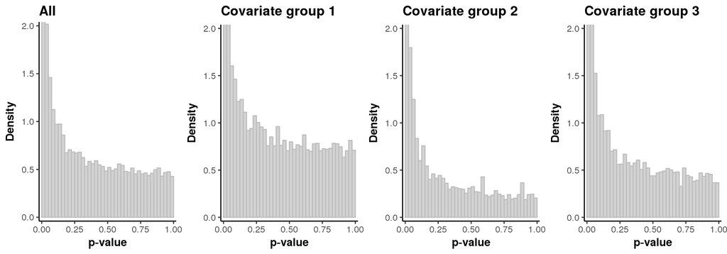

```r
strat_hist(dat, pvalue="pval", covariate="ind_covariate", maxy=2)
```

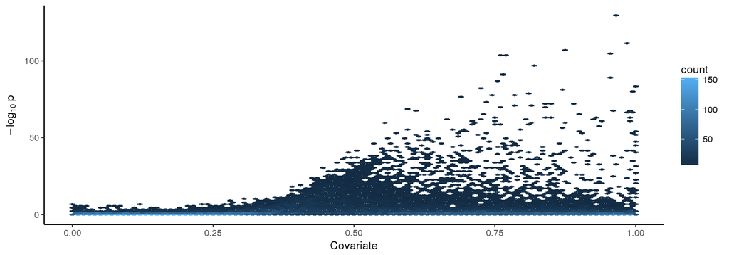

```r
rank_scatter(dat, pvalue="pval", covariate="ind_covariate")
```

#### Setup BenchDesign object

```r
bd <- initializeBenchDesign()
```

#### Run buildBench for the coverage covariate and examine results

Now, we’re ready to construct the `SummarizedBenchmark` object, which will run the functions specified in each method.

```r
resN <- paste0(resdir, "/chipseq_summarizedBenchmark_",
               nrow(dat), ".RData")

duration <- NA
if (!file.exists(resN)){
  t1 <- proc.time()
  sb <- bd %>% buildBench(data=(dat %>% mutate(test_statistic = qnorm(exp(log(pval)-log(2)), lower.tail=FALSE) * sign(effect_size))),
                          ftCols = c("ind_covariate"),
                          parallel=TRUE, BPPARAM=multicoreParam)
  save(sb, file=resN)
  duration <- round((proc.time()-t1)[3]/60,1)
}else{
  load(resN)
}
```

Next, we’ll add the default performance metric for q-value assays. First, we have to rename the assay to ‘qvalue’.

```r
# rename assay to qvalue
assayNames(sb) <- "qvalue"
sb <- addDefaultMetrics(sb)
```

Now, we’ll plot the results.

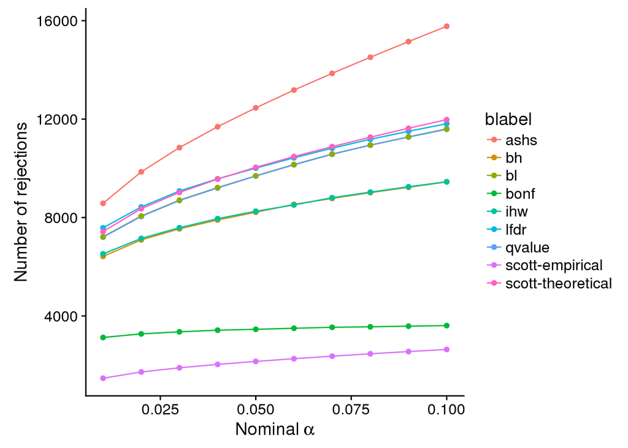

```r
# plot nrejects by method overall and stratified by covariate
rejections_scatter(sb,supplementary=FALSE)
```

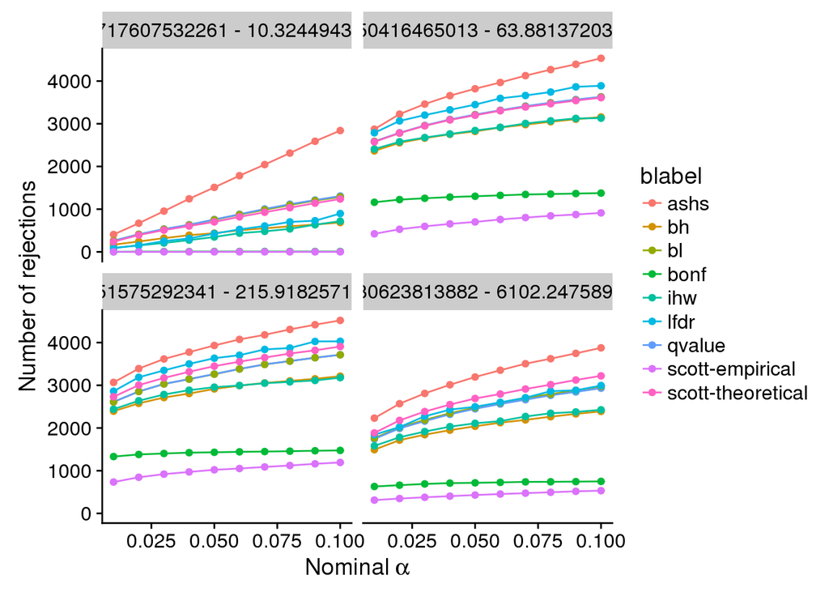

```r
rejection_scatter_bins(sb, covariate="ind_covariate", bins=4,
                       supplementary=FALSE)
```

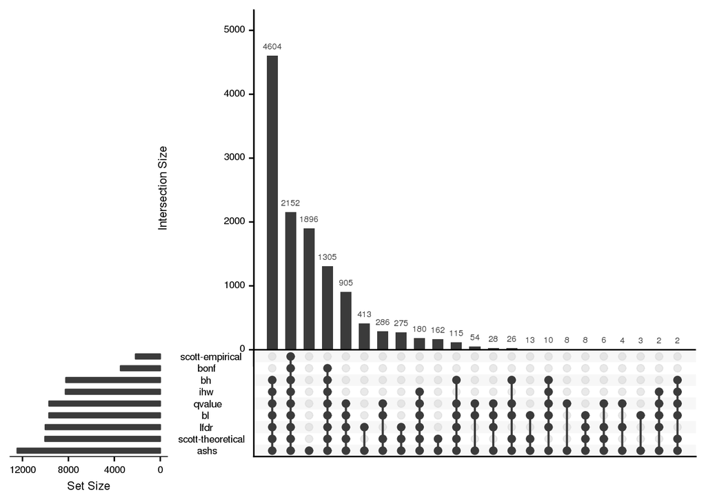

```r
# upset plot
plotFDRMethodsOverlap(sb,
                      alpha=0.05, nsets=ncol(sb),
                      order.by="freq", decreasing=TRUE,
                      supplementary=FALSE)
```

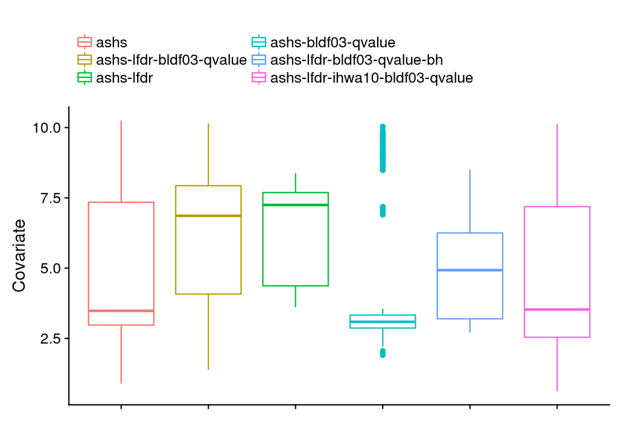

```r
# properties of method-exclusive discoveries
methods <- c("ashs", "lfdr", "ihw-a10", "bl-df03", "qvalue", "bh", "bonf" )
plotCovariateBoxplots(sb, alpha=0.1, nsets=6, methods=methods, trans=log2, maxNum=5)
```

```r
rm(bmi)
rm(bd)
rm(sb)
```